# Random Variables

Nicholas Pearson

2025-09-12

### Random variables

A *random variable* is a variable that can take on a different value based on the outcome of a random experiment. Mathematically speaking a random variable $X$ is a real-valued function on the space of all possible outcomes $\Omega$:
$$X:\Omega\to\mathbb{R}$$

They can be categorized in two main classes: *discrete* and *continuous*.

## Continuous random variables

By definition, a *continuous random variable* is a random variable that can take on an infinite number of values within a certain range. Each variable is defined through the *probability density function* (pdf) as follows:
$$p(x)=Pr(a\leq X \leq b) = \int_{a}^{b}
f(x)dx$$

and the following properties hold:

- $f(x)\geq 0$
- $\int_{-\infty}^{+\infty} f(x)dx=1$

Examples of continuous r.v. are the Gaussian (or Normal distribution), the Chi-squared distribution and the Gamma distribution.

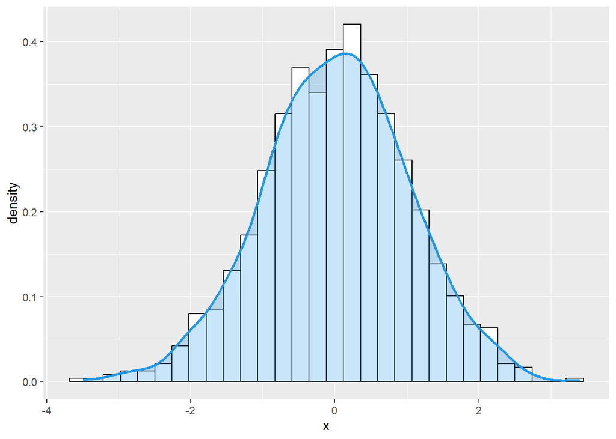

```r
library(ggplot2)

set.seed(5)
x <- rnorm(1000)
df <- data.frame(x)

ggplot(df, aes(x=x)) + geom_histogram(aes(y=..density..), colour=1, fill="white")+ geom_density(lwd=1, colour=4, fill=4, alpha=0.25
                                                                                                )
```

As in the case of discrete random variables, R has built-in functions that can be used to compute the neeeded probabilities. Have a look at:

- `rnorm()`
- `dnorm()`
- `qnorm()`
- `pnorm()`

# Example

Plot the density function of a standard normal distribution, a gaussian distribution with mean 0 and std 1.5 and a normal distribution with mean 3 and variance 2.

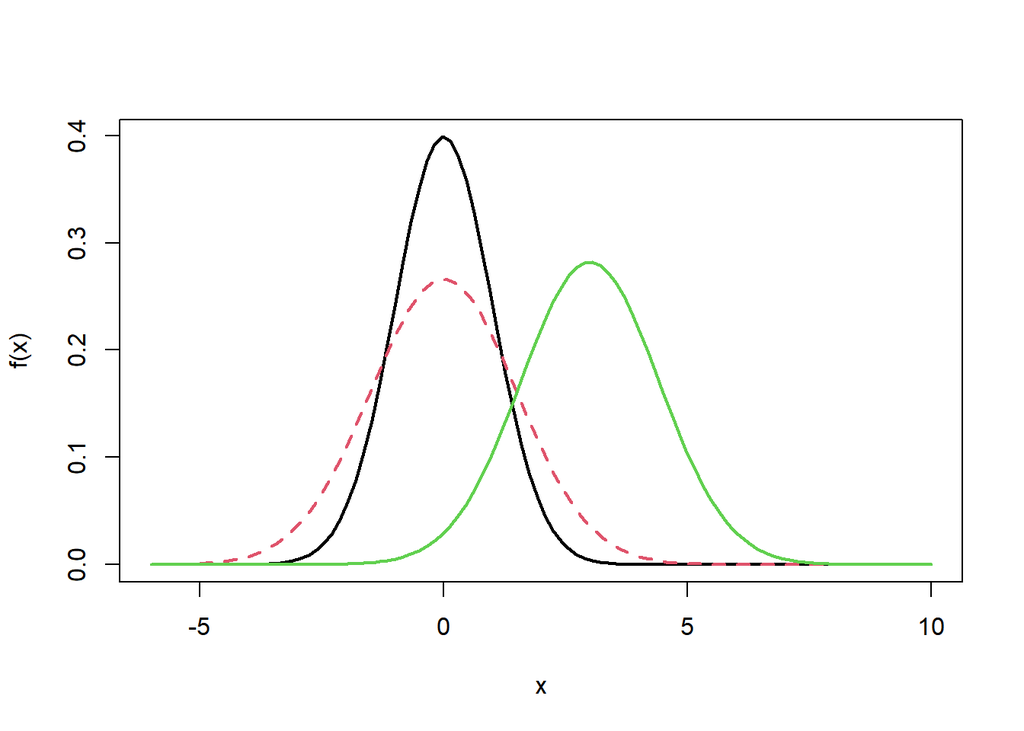

```r
x <- seq(-6, 10, length = 100)
 plot(x, dnorm(x), type="l", xlab="x", ylab= "f(x)", lwd =2)
 curve(dnorm(x, mean=0, sd=1.5), add=TRUE, lty=2, col=2, lwd=2)
 points(x, dnorm(x, mean=3, sd=sqrt(2)), type="l", col=3, lwd=2) #note that it takes as input the std not the variance itseld
```

Let’s have a look at the built-in functions, try to **guess** what each line of code is doing:

```r
dnorm(2)
```

```
## [1] 0.05399097
```

```r
dnorm(2, mean=3, sd=2)
```

```
## [1] 0.1760327
```

```r
dnorm(c(-1,0,1))
```

```
## [1] 0.2419707 0.3989423 0.2419707
```

```r
pnorm(2)
```

```
## [1] 0.9772499
```

```r
qnorm(0.10)
```

```
## [1] -1.281552
```

```r
qnorm(0.90)
```

```
## [1] 1.281552
```

Assume now that a random variable is distributed as a Gaussian with mean $250$ and variance $9$.

```r
mu <- 250
sigma <- 3

p1 <-pnorm(245, mu, sigma)
p1
```

```
## [1] 0.04779035
```

```r
z<- (245-mu)/sigma #what is the name of this operation?
p2 <- pnorm(z) #what are the default values of the mean and the sd according to you?
p2
```

```
## [1] 0.04779035
```

```r
p1==p2 #are the two probabilities identical?
```

```
## [1] TRUE
```

```r
1-pnorm(251, mu, sigma)
```

```
## [1] 0.3694413
```

```r
#this is equivalent to writing
pnorm(251, mu, sigma, lower.tail=FALSE)
```

```
## [1] 0.3694413
```

```r
z1 <- (427-mu)/sigma
z2 <- (253-mu)/sigma

pnorm(z1)-pnorm(z2)
```

```
## [1] 0.1586553
```

```r
Q3 <- qnorm(0.75, 0, 1)
Q1 <- qnorm(0.25, 0, 1)
IQR <- Q3-Q1
IQR
```

```
## [1] 1.34898
```

```r
#how much probability is contained within the IQR ?
```

Create a vector of random variable distributed as a Gaussian with mean 36 and variance 25. Plot the results.

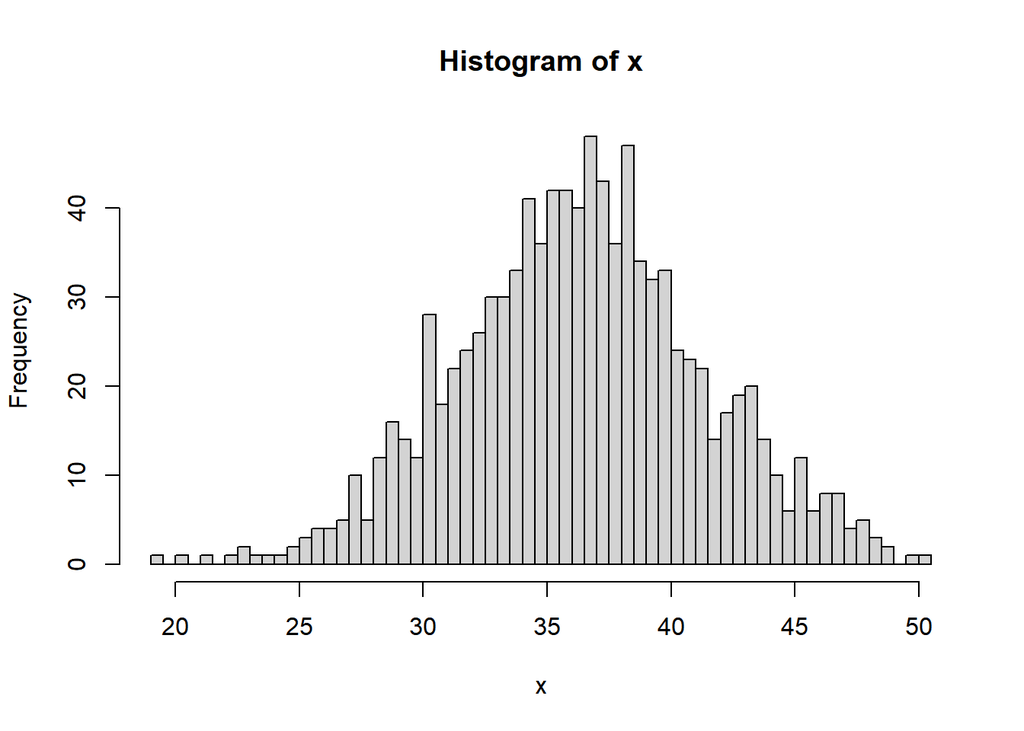

```r
x <- rnorm(1000, mean=36, sd=5)
hist(x, breaks=50)
```

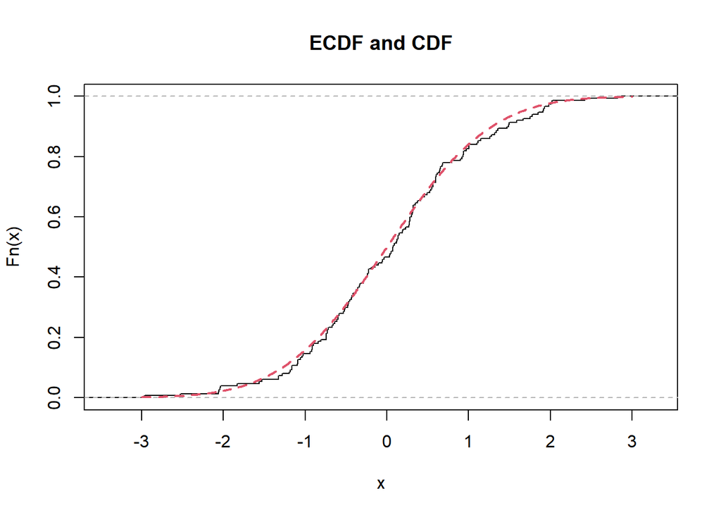

```r
set.seed(991155)
edf_norm <- ecdf(rnorm(150))

tt <- seq(from=-3, to=3, by=0.01)

plot(edf_norm, verticals=TRUE, do.p=FALSE, main="ECDF and CDF")
lines(tt, pnorm(tt), col=2, lty=2, lwd=2)
```

A known theoretical result shows that the distribution of the mean $\mu$ of a Normal distribution, is itself a Normal distribution with known parameters
$$\mathcal{N}(\mu, \sigma^2/n)$$
. Let’s test this with R:

```r
R <- 1000
n <- 30
means <- vector(mode="numeric", length=R)

for (i in 1:R){
  x <- rnorm(n)
  means[i] <- mean(x)
}
mean(means)
```

```
## [1] 0.0001270866
```

```r
var(means)
```

```
## [1] 0.03474316
```

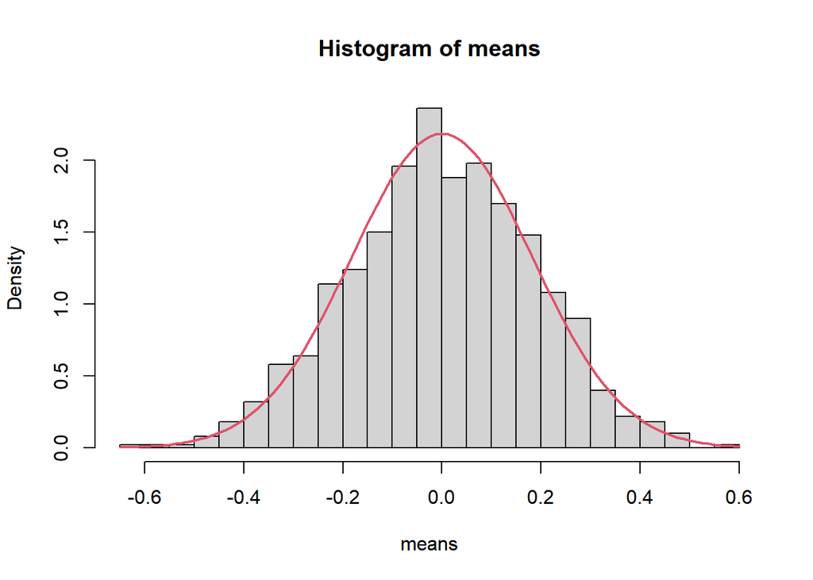

```r
hist(means, breaks=30, prob=TRUE)
curve(dnorm(x, mean=0, sd=sqrt(1/n)), col=2, lwd=2, add=T) #why mean = 0 and sd = sqrt(1/n) ?
```

## Your turn!

1. Let $Z$ be the standard normal distribution. Compute:

a. $Pr(Z<1)$  
b. $Pr(Z>1)$  
c. $Pr(Z<-1)$  
d. $Pr(0.3 < Z < 0.5)$

```r
pnorm(1)
```

```
## [1] 0.8413447
```

```r
1 - pnorm(1)
```

```
## [1] 0.1586553
```

```r
#or
pnorm(1, lower.tail=FALSE)
```

```
## [1] 0.1586553
```

```r
pnorm(-1)
```

```
## [1] 0.1586553
```

```r
pnorm(0.5)-pnorm(0.3)
```

```
## [1] 0.07355104
```

```r
#or
diff(pnorm(c(0.3, 0.5)))
```

```
## [1] 0.07355104
```

2. Plot the density distribution of a Gaussian distribution with mean $\mu=0$ and varying values of the standard deviation, say $\sigma \in (0.8, 1.3, 1.9)$. For the same parameters, plot the cumulative density function plot.

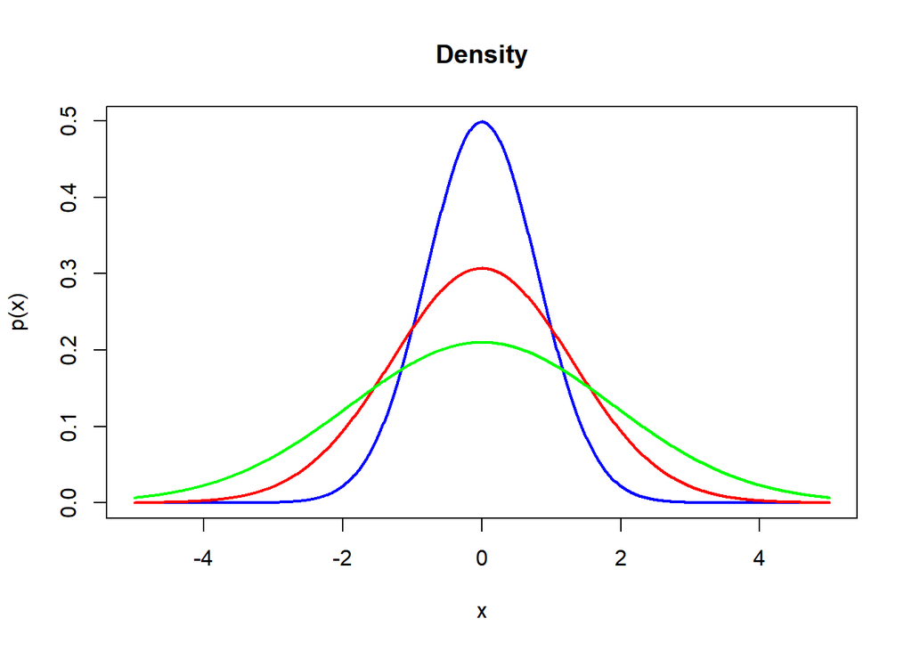

```r
x <- seq(-5, 5, 0.01)

plot(x, dnorm(x, mean = 0, sd=0.8), type="l", col="blue", lwd=2, xlab="x", ylab="p(x)", main= "Density")
lines(x, dnorm(x, mean=0, sd=1.3), col="red", lwd=2)
lines(x, dnorm(x, mean=0, sd=1.9), col="green", lwd=2)
```

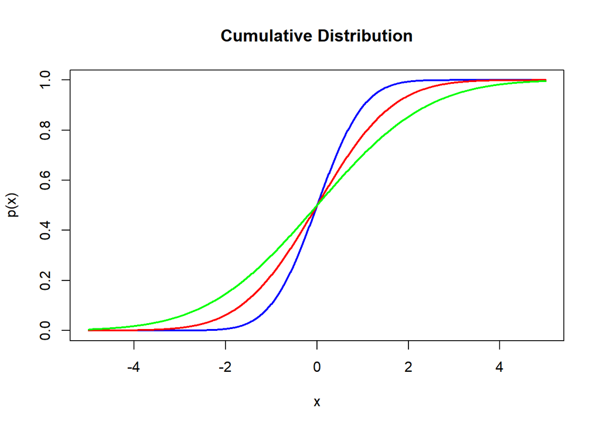

```r
plot(x, pnorm(x, mean = 0, sd=0.8), type="l", col="blue", lwd=2, xlab="x", ylab="p(x)", main ="Cumulative Distribution")
lines(x, pnorm(x, mean=0, sd=1.3), col="red", lwd=2)
lines(x, pnorm(x, mean=0, sd=1.9), col="green", lwd=2)
```

```r
mu <- 3
std <- 4.5
diff(pnorm(c(2.1, 4.5), mu, std))
```

```
## [1] 0.2098184
```

```r
pnorm(3.5, mu, std)
```

```
## [1] 0.5442359
```

```r
pnorm(2.3, mu, std, lower.tail=FALSE)
```

```
## [1] 0.5618083
```

4. Write a function that, given a vector, compute its mean, its standard deviation and return the standardized values.

```r
standardize <- function(x) {
  mu <- mean(x)
  std <- sd(x)

  x_st <- (x-mu)/std

  return(x_st)
  }
```

5. Generate $n=1000$ points from a Normal distribution with mean and standard deviation of your choice. Standardize your data with the function of point 4. and compare the results with the Standard Normal distribution via an appropriate visualization.

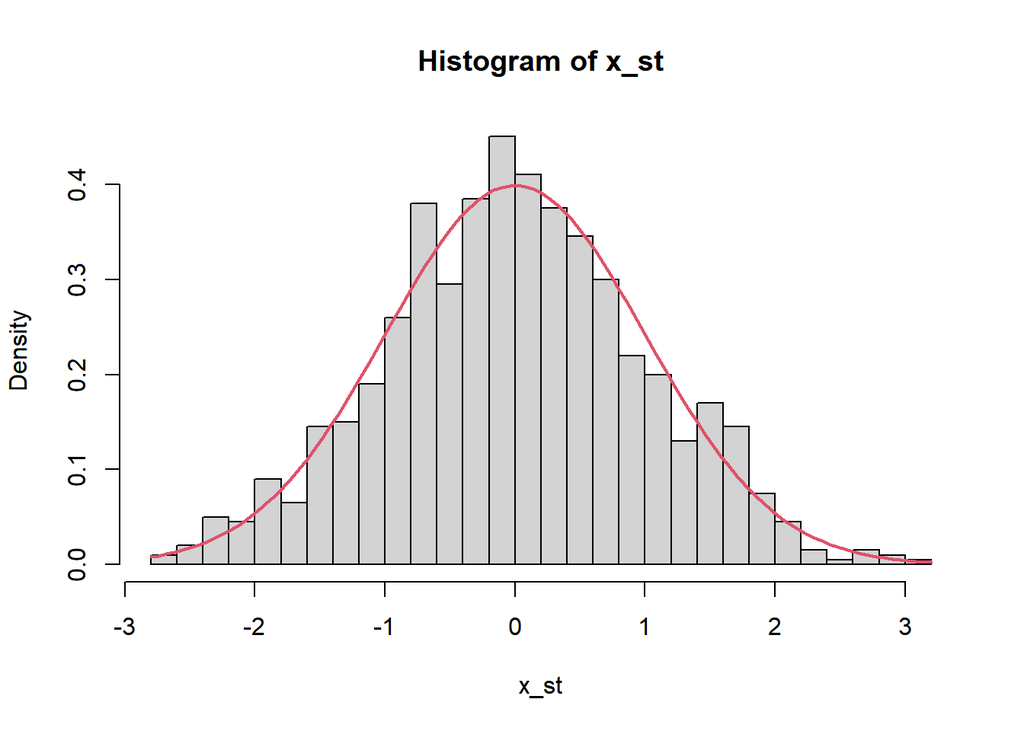

```r
n <- 1000
mu <- 10
std <- 2

x_r <- rnorm(n, mu, std)
x_st <- standardize(x_r)

x <- seq(-3, 3, 0.01)
hist(x_st, breaks=30, prob=TRUE)
curve(dnorm(x), col=2, lwd=2, add=T)
```

6. Compare in a single graph the cumulative distribution function of an exponential random variable with parameter $\lambda \in (1,5,10)$. For each of these distributions, compute the quantiles at level $q\in(0.75, 0.80, 0.95)$.

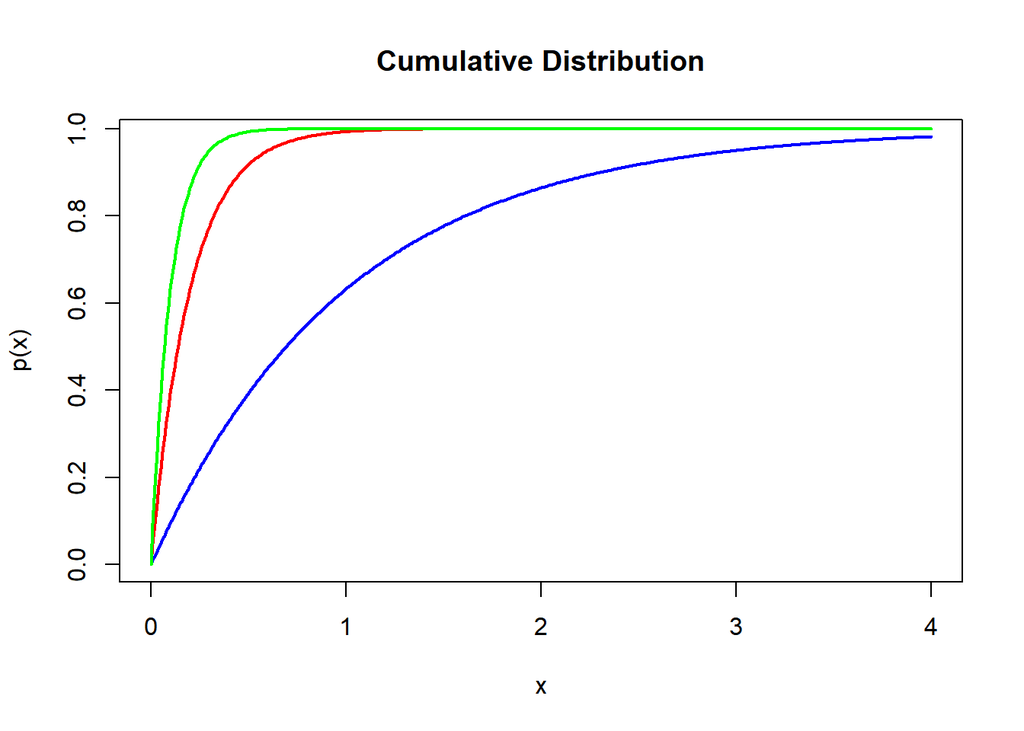

```r
x <- seq(0,4, 0.01)

plot(x, pexp(x, rate=1), type="l", col="blue", lwd=2, xlab="x", ylab="p(x)", main ="Cumulative Distribution")
lines(x, pexp(x, rate=5 ), col="red", lwd=2)
lines(x, pexp(x, rate=10), col="green", lwd=2)
```

```r
qexp(c(0.75, 0.80, 0.95), rate=1)
```

```
## [1] 1.386294 1.609438 2.995732
```

```r
qexp(c(0.75, 0.80, 0.95), rate=5)
```

```
## [1] 0.2772589 0.3218876 0.5991465
```

```r
qexp(c(0.75, 0.80, 0.95), rate=10)
```

```
## [1] 0.1386294 0.1609438 0.2995732
```

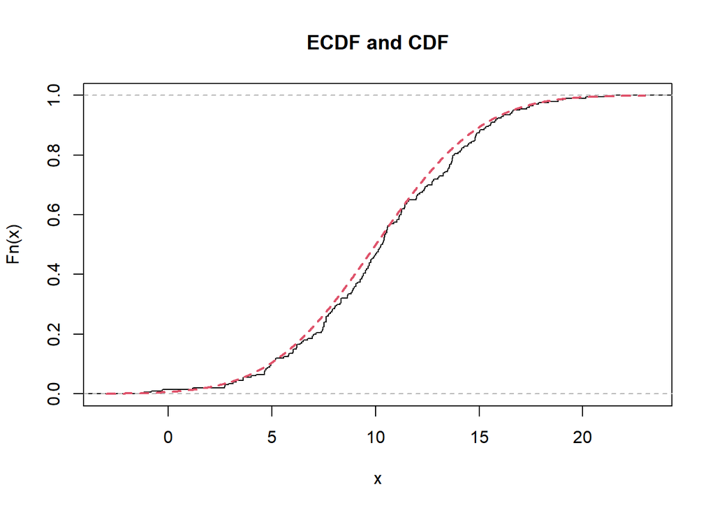

```r
n <- 200
mu <- 10
std <- 4

x_norm <- rnorm(n, mu, std)
x <- seq(-3, 23, 0.01)


plot(ecdf(x_norm), verticals=TRUE, do.p=FALSE, main="ECDF and CDF")
lines(x, pnorm(x, mu, std), col=2, lty=2, lwd=2)
```

```r
mu <- 1200
std <- 100

pnorm(1000, mu, std, lower.tail = TRUE)
```

```
## [1] 0.02275013
```

```r
diff(pnorm(c(1100, 1300), mu,std))
```

```
## [1] 0.6826895
```

```r
q<-qnorm(p=0.10, mean=mu, sd=std, lower.tail=FALSE)
q
```

```
## [1] 1328.155
```

```r
pnorm(q, mu, std, lower.tail=FALSE)
```

```
## [1] 0.1
```

9. Find the Q1, Q2 and Q3 of the standard normal distribution. What is the probability that a value is within the interquartile range?

```r
q1 <- qnorm(0.25)
q1
```

```
## [1] -0.6744898
```

```r
q2 <- qnorm(0.5)
q2
```

```
## [1] 0
```

```r
q3 <- qnorm(0.75)
q3
```

```
## [1] 0.6744898
```

```r
diff(pnorm(c(q1,q3)))
```

```
## [1] 0.5
```

10. The average time a person spends at the Barefoot Landing Seaquarium is 96 minutes. The standard deviation is 17 minutes. Assume the variable is normally distributed. a. If a visitor is selected at random, find the probability that he or she will spend at least 120 minutes at the seaquarium. b. If a visitor is selected at random, find the probability that he or she will spend at most 80 minutes at the seaquarium. c. Suggest a time for a bus to return to pick up a group of tourists

```r
mu <- 96
std <- 17

1 - pnorm(120, mu, std)
```

```
## [1] 0.07900963
```

```r
pnorm(80, mu, std)
```

```
## [1] 0.1733072
```

```r
qnorm(0.95, mu, std)
```

```
## [1] 123.9625
```

```r
mu <- 36.7
std <- 0.4

qnorm(c(0.05, 0.95), mu, std)
```

```
## [1] 36.04206 37.35794
```

```r
pnorm(37, mu, std, lower.tail=FALSE)
```

```
## [1] 0.2266274
```

```r
qnorm(0.20, mu, std)
```

```
## [1] 36.36335
```

12. Have a look at the functions for the Student’t distribution. For an increasing number of degrees of freedom $\nu\in(1, 5, 10,100,1000)$, plot the density function and compare the results to the standard normal distribution.

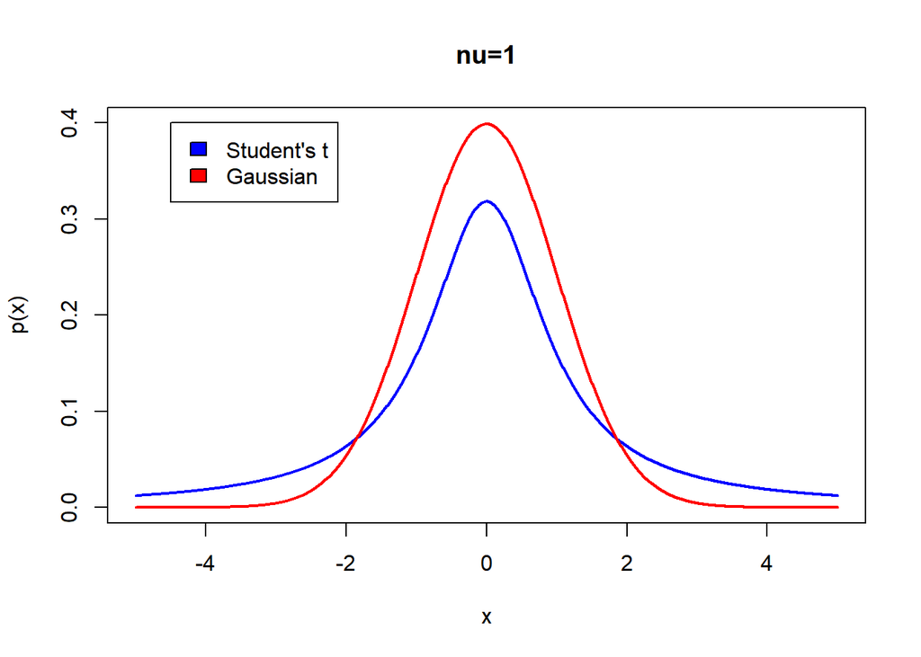

```r
x <- seq(-5, 5, 0.01)

plot(x, dt(x, df = 1), type="l", col="blue", lwd=2, xlab="x", ylab="p(x)", main= "nu=1", ylim=c(0, 0.4))
lines(x, dnorm(x), col="red", lwd=2)
legend(-4.5, 0.4, legend=c("Student's t", "Gaussian"), fill = c("blue","red"))
```

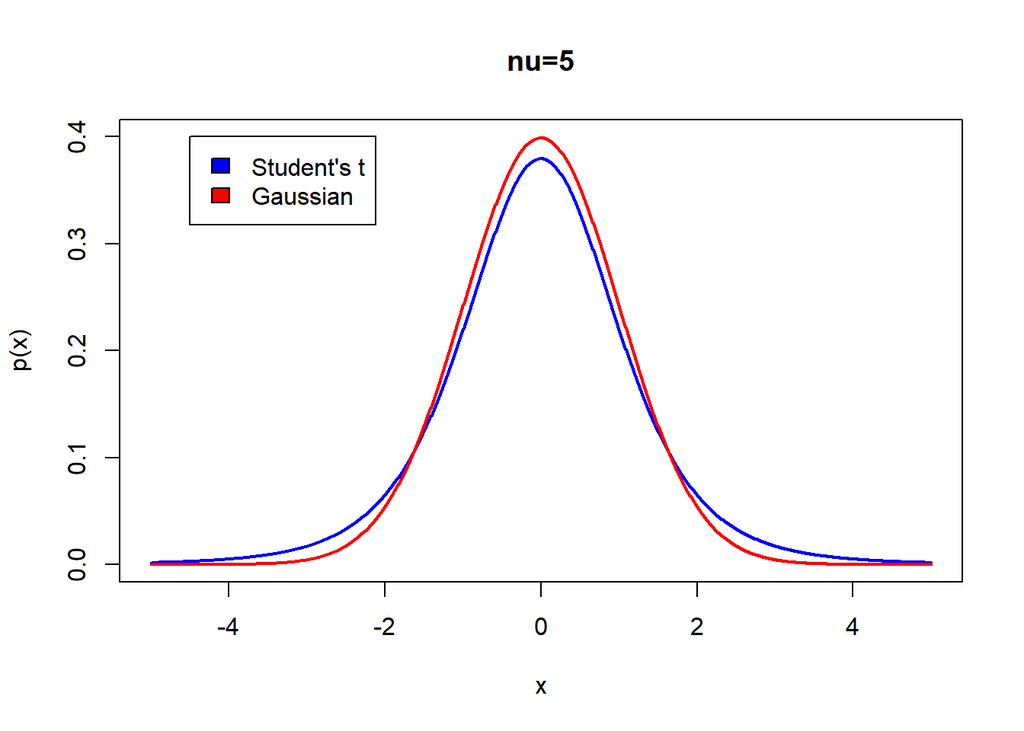

```r
plot(x, dt(x, df = 5), type="l", col="blue", lwd=2, xlab="x", ylab="p(x)", main= "nu=5", ylim=c(0, 0.4))
lines(x, dnorm(x), col="red", lwd=2)
legend(-4.5, 0.4, legend=c("Student's t", "Gaussian"), fill = c("blue","red"))
```

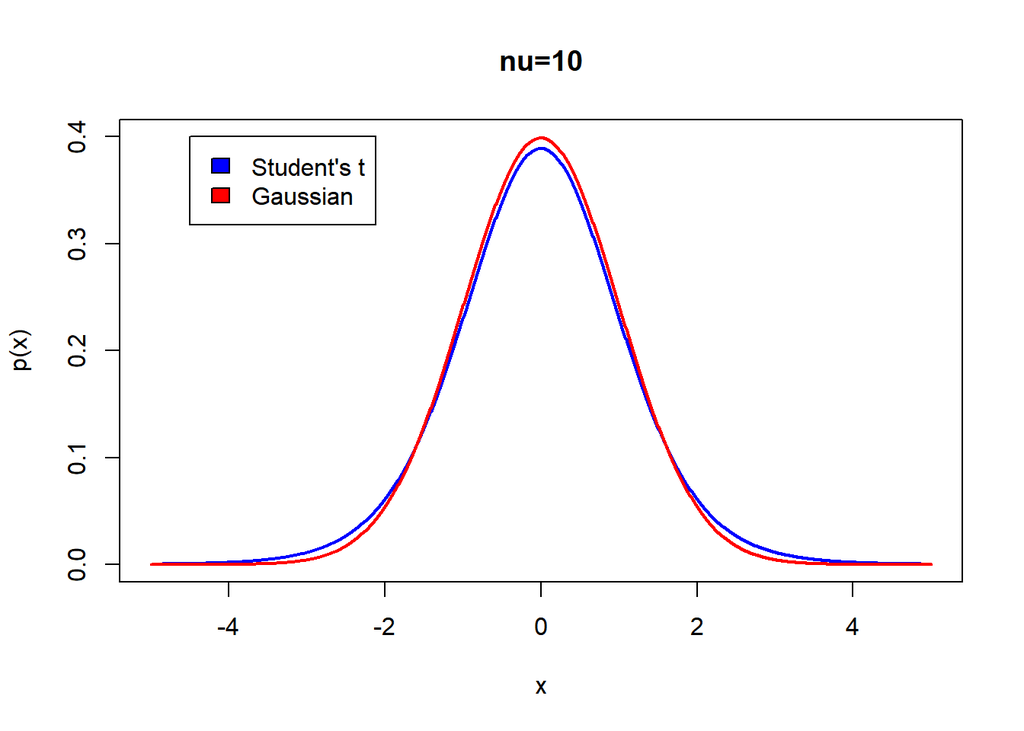

```r
plot(x, dt(x, df = 10), type="l", col="blue", lwd=2, xlab="x", ylab="p(x)", main= "nu=10", ylim=c(0, 0.4))
lines(x, dnorm(x), col="red", lwd=2)
legend(-4.5, 0.4, legend=c("Student's t", "Gaussian"), fill = c("blue","red"))
```

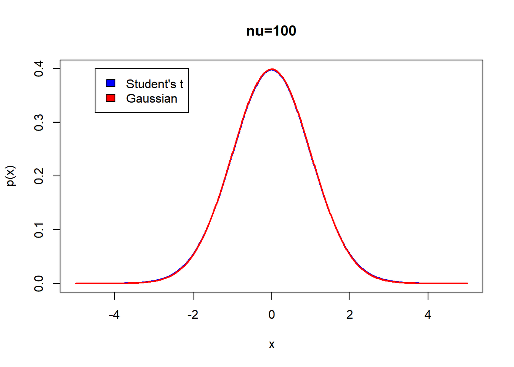

```r
plot(x, dt(x, df = 100), type="l", col="blue", lwd=2, xlab="x", ylab="p(x)", main= "nu=100", ylim=c(0, 0.4))
lines(x, dnorm(x), col="red", lwd=2)
legend(-4.5, 0.4, legend=c("Student's t", "Gaussian"), fill = c("blue","red"))
```

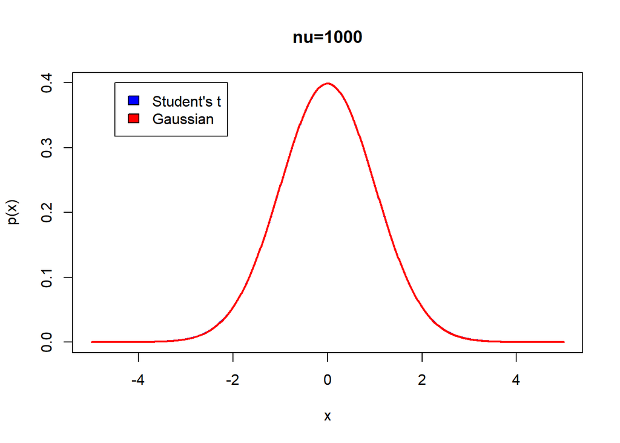

```r
plot(x, dt(x, df = 1000), type="l", col="blue", lwd=2, xlab="x", ylab="p(x)", main= "nu=1000", ylim=c(0, 0.4))
lines(x, dnorm(x), col="red", lwd=2)
legend(-4.5, 0.4, legend=c("Student's t", "Gaussian"), fill = c("blue","red"))
```

13. Some other theoretical results show that: a. A binomial distribution is approximately normal with mean $np$ and variance $np(1-p)$ for large $n$ and $p$ not too close neither to 0 nor to 1 b. A Poisson distribution with parameter $\lambda$ is approximately normal with mean $\lambda$ and variance $\lambda$ for large values of $\lambda$.

Verify both results by plotting the density function agains that of a propertly defined normal distribution.

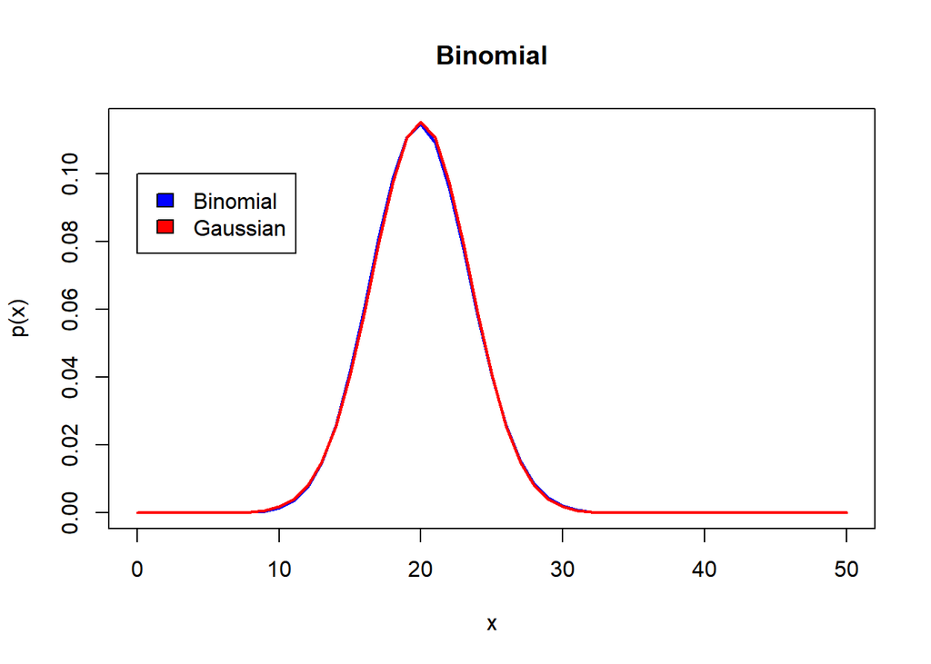

```r
n <- 50
p <- 0.4
x <- seq(0, 50, 1)
plot(x, dbinom(x, n, p), type="l", col="blue", lwd=2, xlab="x", ylab="p(x)", main= "Binomial")
lines(x, dnorm(x, mean = n*p, sd = sqrt(n*p*(1-p))), col="red", lwd=2)
legend(0, 0.10, legend=c("Binomial", "Gaussian"), fill = c("blue","red"))
```

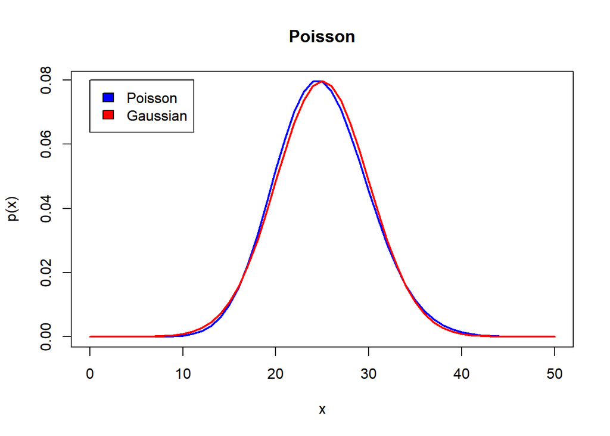

```r
l <- 25
x <- seq(0, 50, 1)
plot(x, dpois(x, lambda = l), type="l", col="blue", lwd=2, xlab="x", ylab="p(x)", main= "Poisson")
lines(x, dnorm(x, mean = l, sd = sqrt(l)), col="red", lwd=2)
legend(0, 0.08, legend=c("Poisson", "Gaussian"), fill = c("blue","red"))
```